# Data analysis and Visualization

Renxiao Deng

2026-03-07

```r
#install.packages("survival")
#install.packages("survminer")
```

```r
library(tidyverse)
library(janitor)
library(readxl)
library(survival)
library(survminer)
```

## Importing Cleaned data

```r
result %>% summary()
```

```
##        no             center       tnm_stage         overall_response_y_n
##  Min.   :  1.00   Min.   :1.000   Length:390         Length:390
##  1st Qu.: 98.25   1st Qu.:6.000   Class :character   Class :character
##  Median :195.50   Median :6.000   Mode  :character   Mode  :character
##  Mean   :195.50   Mean   :5.831
##  3rd Qu.:292.75   3rd Qu.:6.000
##  Max.   :390.00   Max.   :7.000
##   itt_group         safety_set        pp_set        pathological_type
##  Length:390         Mode :logical   Mode :logical   Length:390
##  Class :character   FALSE:15        FALSE:20        Class :character
##  Mode  :character   TRUE :375       TRUE :370       Mode  :character
##
##
##
##     t_stage         n_stage         m_stage       kps
##  Min.   :1.000   Min.   :0.000   Min.   :0   Min.   : 80.00
##  1st Qu.:3.000   1st Qu.:1.000   1st Qu.:0   1st Qu.: 90.00
##  Median :3.000   Median :2.000   Median :0   Median : 90.00
##  Mean   :3.249   Mean   :2.092   Mean   :0   Mean   : 89.95
##  3rd Qu.:4.000   3rd Qu.:3.000   3rd Qu.:0   3rd Qu.: 90.00
##  Max.   :4.000   Max.   :3.000   Max.   :0   Max.   :100.00
##  imaging_after_3_cycles_of_ic ebv_clearance_status survival_y_n
##  Length:390                   Mode :logical        Mode :logical
##  Class :character             FALSE:131            FALSE:363
##  Mode  :character             TRUE :259            TRUE :27
##
##
##
##        os         progression_y_n      pfs        recurrence_y_n
##  Min.   : 3.867   Mode :logical   Min.   : 2.10   Mode :logical
##  1st Qu.:36.150   FALSE:290       1st Qu.:34.45   FALSE:340
##  Median :39.283   TRUE :100       Median :38.07   TRUE :50
##  Mean   :38.783                   Mean   :34.61
##  3rd Qu.:43.125                   3rd Qu.:41.90
##  Max.   :50.500                   Max.   :50.50
##      lrrfs       metastasis_y_n       dmfs
##  Min.   : 2.10   Mode :logical   Min.   : 2.10
##  1st Qu.:34.45   FALSE:328       1st Qu.:34.45
##  Median :38.07   TRUE :62        Median :38.05
##  Mean   :34.60                   Mean   :34.59
##  3rd Qu.:41.90                   3rd Qu.:41.90
##  Max.   :50.50                   Max.   :50.50
```

Notes:

first will be evaluate the impact on survival rate of different stage of cancer

responded to induction chemotherapy means if the chemotherapy is effective or not before the test trial

safety set count and pp set count in table(safety set means the patient at least received chemotherapy; pp set means the patient at least received 3 cycles of chemotherapy and imaging after 3 cycles of chemotherapy)

Categorizing Variables:

Patient Status Before Treatment: cancer TNM stage, respond to chemotherapy or not, kps, in safety set or ppset or not

Results: os(only consider False in survival yn), pfs, irrfs, dmfs,(those 3 only consider true in corresponding column) and imaging_after_3_cycles_of_ic, also ebv clearance status(virus associated with this type of cancer)

Plotting plan

Data exploration: TNM stage, respond to chemotherapy or not, kps, and survival status (bar plot)

Additionally, the survival expectancy with respect to different TNM stage, respond to chemotherapy or not, kps (line plot)

Effect on imaging after 3 cycles of chemotherapy (bar plot)

Effect of the novel treatment: on survival status, pfs, irrfs, dmfs, and (line plot)

*compare with control group: to those not in safety set or pp set (a shiny app feature)

## Data exploration: TNM stage, respond to chemotherapy or not, kps, and survival status (bar plot)

TNM stage by detailed splitting

Note: each stage has the base of entire population and patients experienced different sub-stages in each TNM stage

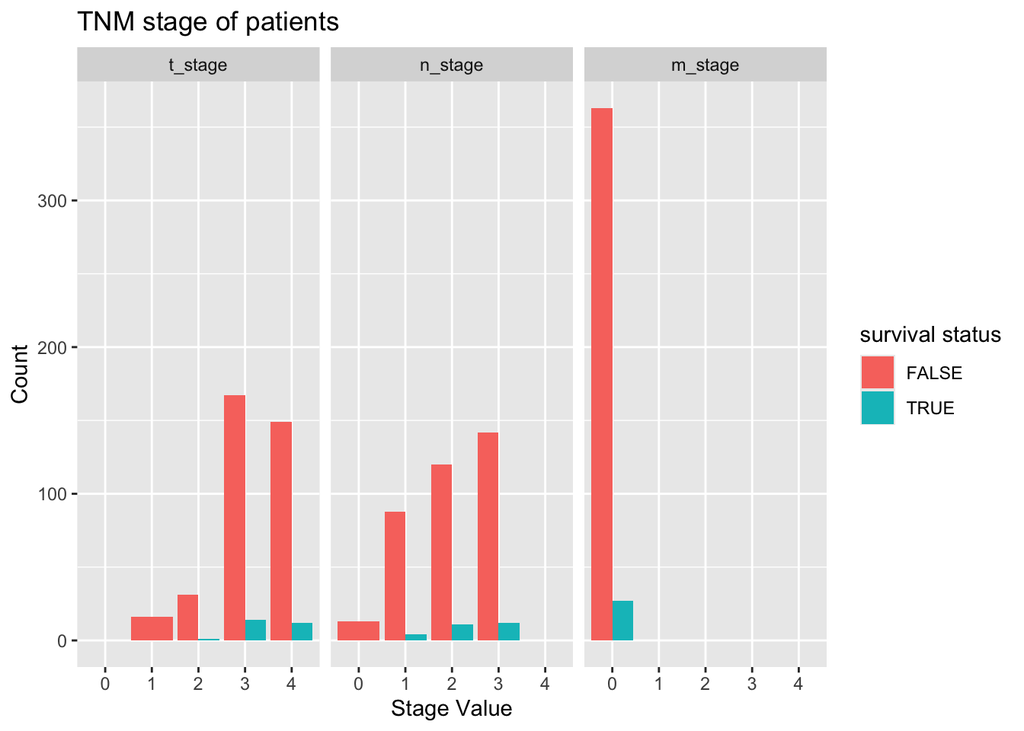

```r
result_long <- result %>%
  pivot_longer(cols = c("t_stage","n_stage","m_stage"), names_to = "stage_type", values_to = "stage_value")%>%
  mutate(stage_type = factor(stage_type,
                             levels = c("t_stage", "n_stage", "m_stage")))
result_long %>% ggplot(aes(x=factor(stage_value),fill=survival_y_n)) +
  geom_bar(position = "dodge") +
  facet_wrap(~stage_type,nrow = 1) +
  labs(title = "TNM stage of patients", x = "Stage Value", y = "Count", fill="survival status")
```

Count for respond to chemotherapy or not

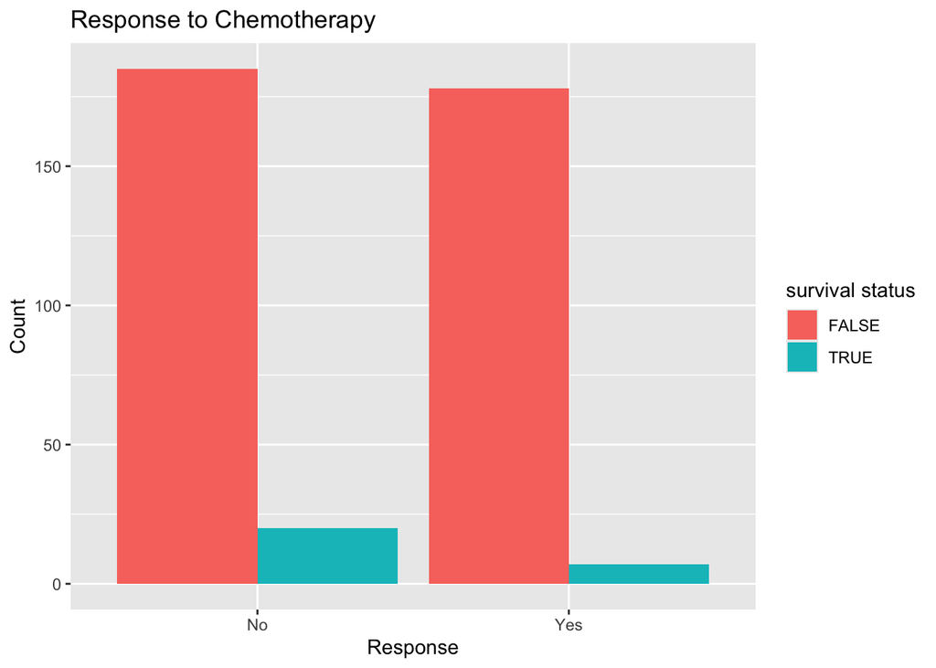

```r
result %>% ggplot(aes(x=overall_response_y_n,fill=survival_y_n)) +
  geom_bar(position = "dodge") +
  labs(title = "Response to Chemotherapy", x = "Response", y = "Count",fill="survival status")
```

Karnofsky Performance Status

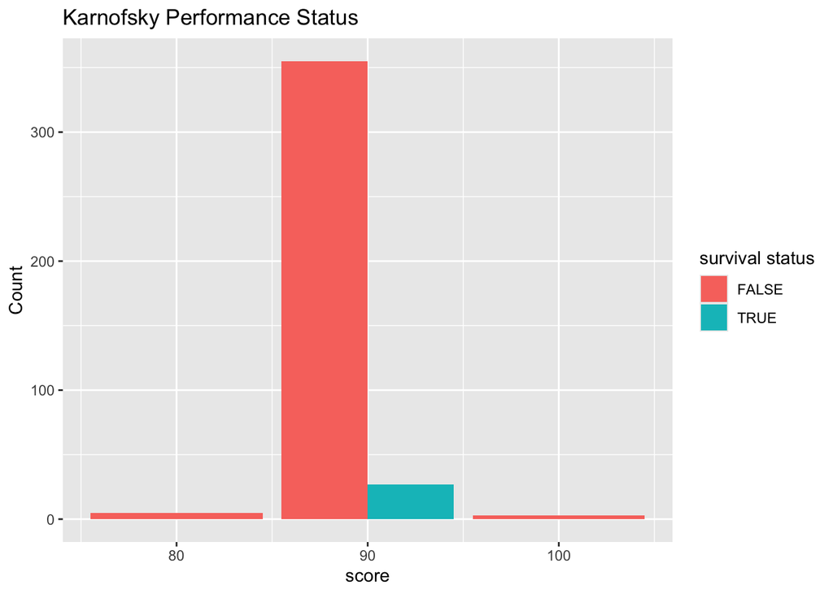

```r
result %>% ggplot(aes(x=kps,fill=survival_y_n)) +
  geom_bar(position = "dodge") +
  labs(title = "Karnofsky Performance Status", x = "score", y = "Count",fill="survival status")
```

Overall Survival with respect to overal response to chemotherapy

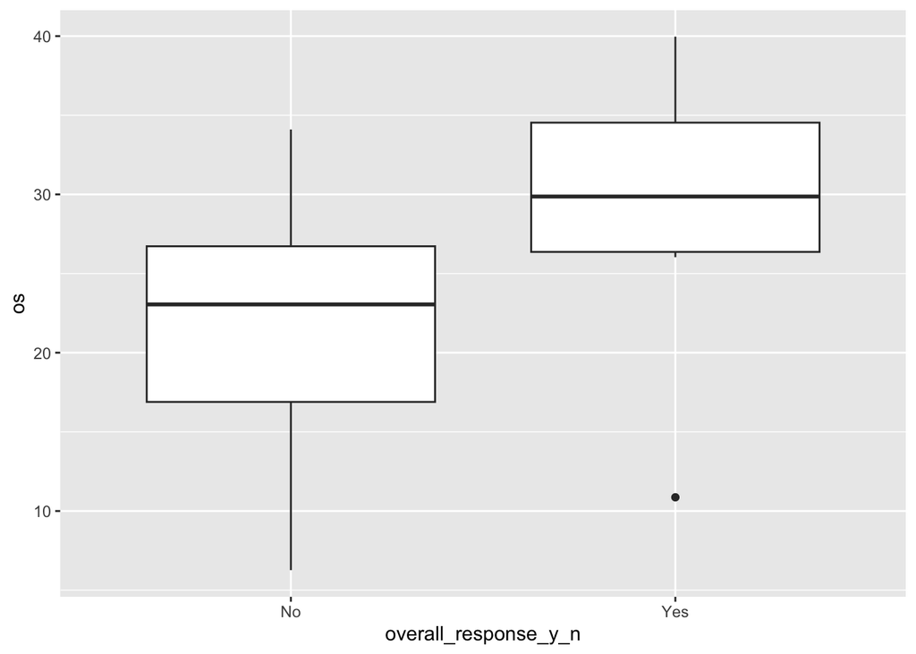

```r
result %>%
  filter(survival_y_n == TRUE) %>%
ggplot(aes(x = overall_response_y_n, y = os)) +
  geom_boxplot()
```

Critical

ORR PR+CR/total DCR (Disease control rate) PR+CR+SD/total Find mpfs(Don’t calculate mean, because it depends so much on patient) DOR (Duration of response) time from first response to progression or death (also calculate the median)

Waterfall Charts Do for ORR

Spider plot

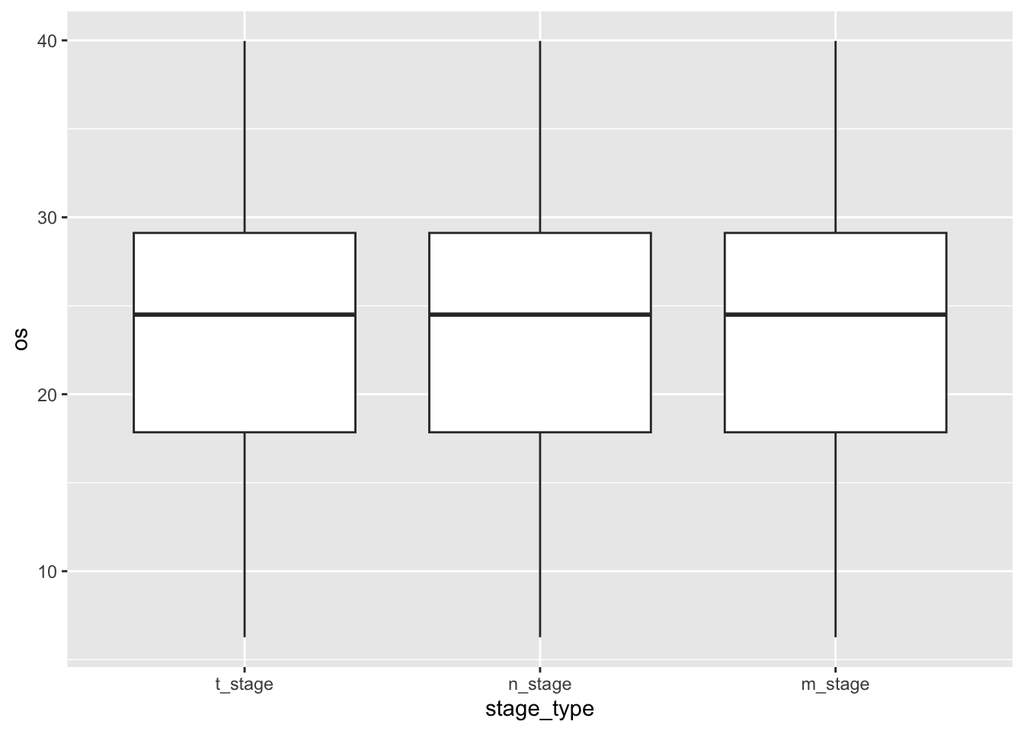

```r
result_long %>%
  filter(survival_y_n == TRUE) %>%
ggplot(aes(x = stage_type, y = os)) +
  geom_boxplot()
```

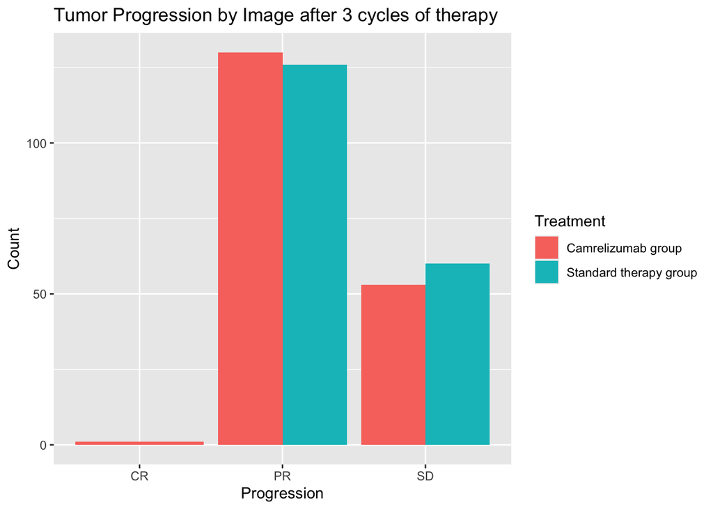

```r
result %>%
  filter(pp_set == "TRUE") %>%
  ggplot(aes(x=imaging_after_3_cycles_of_ic,fill=itt_group)) +
  geom_bar(position = "dodge") +
  labs(title = "Tumor Progression by Image after 3 cycles of therapy", x = "Progression", y = "Count", fill="Treatment")
```

# Data Re-organization

```r
km_curve  <- result %>%
  mutate(
    survival_event = case_when(
      survival_y_n == FALSE ~ 0,
      survival_y_n == TRUE ~ 1
    ),
    progression_event = case_when(
      progression_y_n == FALSE ~ 0,
      progression_y_n == TRUE ~ 1
    ),
    recurrence_event = case_when(
      recurrence_y_n == FALSE ~ 0,
      recurrence_y_n == TRUE ~ 1
    ),
    metastasis_event = case_when(
      metastasis_y_n == FALSE ~ 0,
      metastasis_y_n == TRUE ~ 1
    )
  )#Convert back to 1 and 0s
```

# Kaplan–Meier curve for overall survival

```r
fit_os <- survfit(Surv(os, survival_event) ~ itt_group, data = km_curve)
#tells R to estimate one curve per treatment group
```

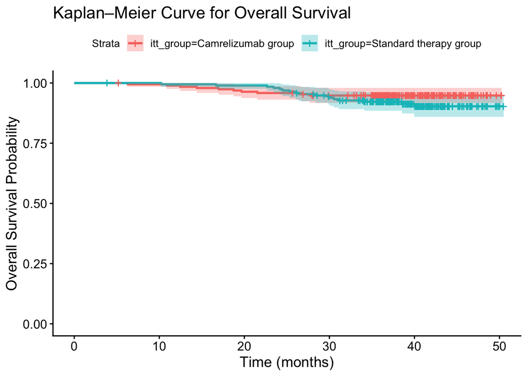

```r
ggsurvplot(
  fit_os,
  data = km_curve,
  xlab = "Time (months)",
  ylab = "Overall Survival Probability",
  title = "Kaplan–Meier Curve for Overall Survival",
  conf.int = TRUE,
)
```

# Kaplan–Meier curve for Progression-Free Survival

```r
fit_progression <- survfit(Surv(pfs, progression_event) ~ itt_group, data = km_curve)
#tells R to estimate one curve per treatment group
```

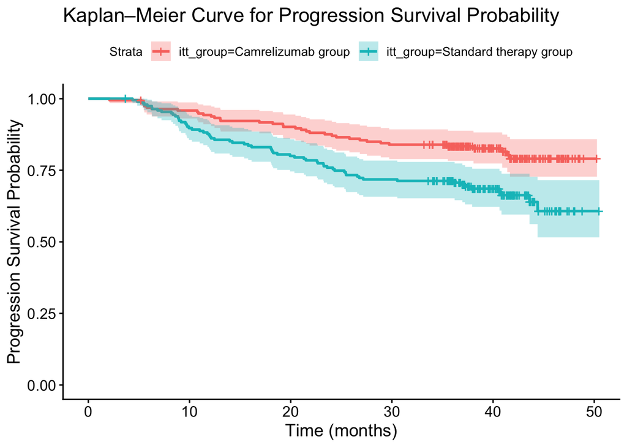

```r
ggsurvplot(
  fit_progression,
  data = km_curve,
  xlab = "Time (months)",
  ylab = "Progression Survival Probability",
  title = "Kaplan–Meier Curve for Progression Survival Probability",
  conf.int = TRUE,
)
```

# Kaplan–Meier curve for Recurrence-Free Survival

```r
fit_recurrence <- survfit(Surv(pfs, recurrence_event) ~ itt_group, data = km_curve)
#tells R to estimate one curve per treatment group
```

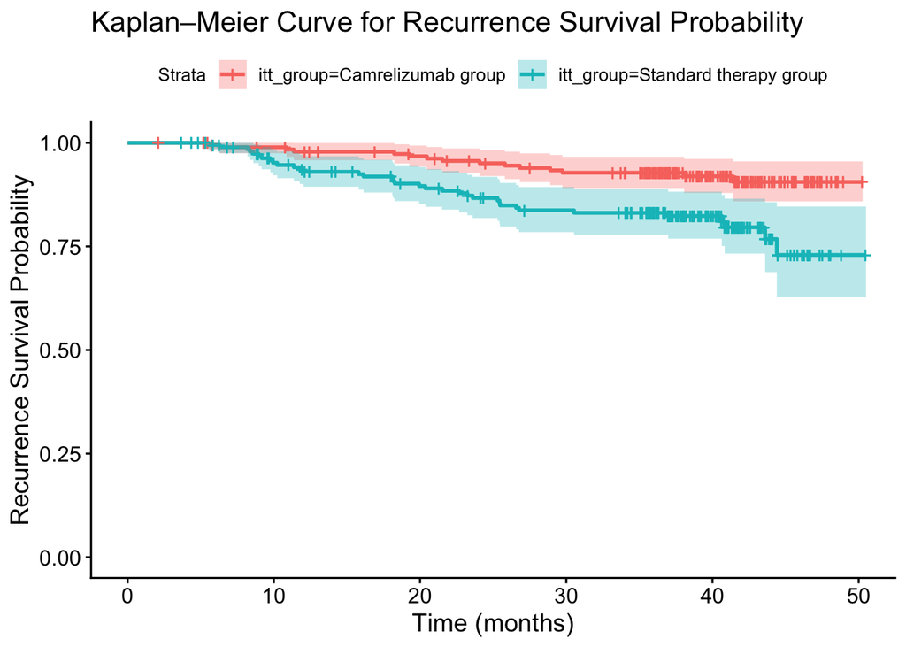

```r
ggsurvplot(
  fit_recurrence,
  data = km_curve,
  xlab = "Time (months)",
  ylab = "Recurrence Survival Probability",
  title = "Kaplan–Meier Curve for Recurrence Survival Probability",
  conf.int = TRUE,
)
```

# Kaplan–Meier curve for Metastasis-Free Survival

```r
fit_metastasis <- survfit(Surv(pfs, metastasis_event) ~ itt_group, data = km_curve)
#tells R to estimate one curve per treatment group
```

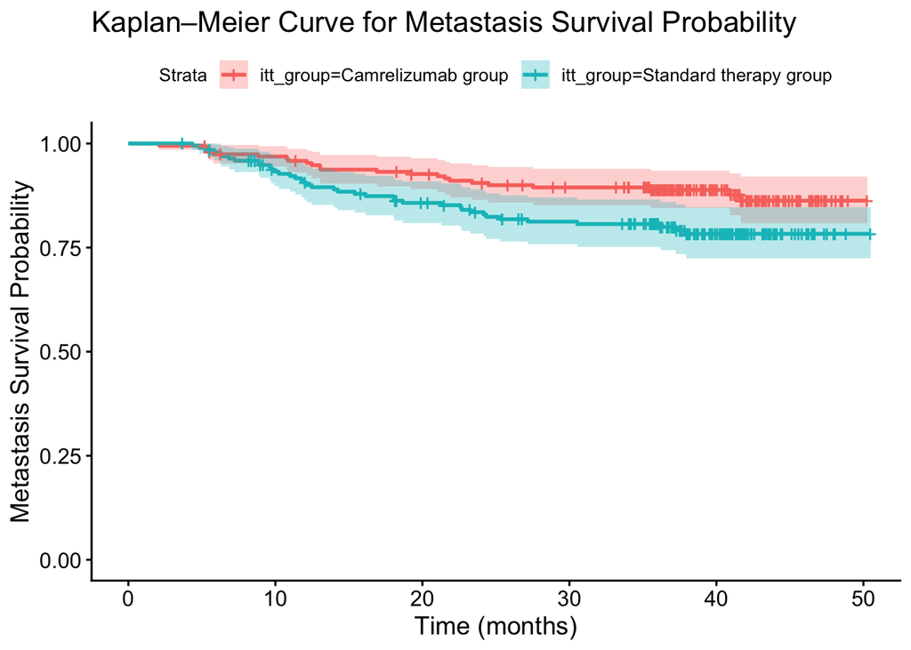

```r
ggsurvplot(
  fit_metastasis,
  data = km_curve,
  xlab = "Time (months)",
  ylab = "Metastasis Survival Probability",
  title = "Kaplan–Meier Curve for Metastasis Survival Probability",
  conf.int = TRUE,
)
```

# Swimming Plot for patients

Step1: organize into new base for swimplot

```r
swim_base <- result %>%
  transmute(
    no,
    itt_group,
    followup_time = os,
    recurrence_time = if_else(recurrence_y_n == TRUE, lrrfs, NA_real_),
    metastasis_time = if_else(metastasis_y_n == TRUE, dmfs, NA_real_),
    progression_time = if_else(progression_y_n == TRUE, pfs, NA_real_),
    death_time = if_else(survival_y_n == TRUE, os, NA_real_)
  )
```

Step2: Pivot longer for better analysis

```r
swim_event <- swim_base %>%
  pivot_longer(
    cols = c(recurrence_time, metastasis_time, progression_time, death_time),
    names_to = "event_type",
    values_to = "event_time"
  )%>%
  filter(!is.na(event_time))
```

Step3: Arrange the patients by their follow up time as patient order

```r
swim_order <- swim_base %>%
  arrange(followup_time) %>%
  mutate(order = row_number())

swim_event <-
  left_join(swim_event,swim_order %>% select(no, order),by = "no")
```

Step 4: Final plotting

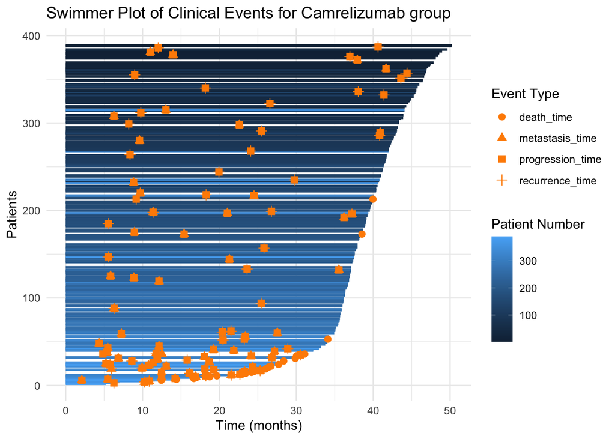

```r
swim_order %>%
  filter(itt_group == "Camrelizumab group") %>%
  ggplot() +
  geom_segment(
    aes(x = 0, xend = followup_time,
      y = order, yend = order,
      color = no),
    linewidth = 1) +
  geom_point(
    data = swim_event,
    aes(
      x = event_time,
      y = order,
      shape = event_type
    ),
    size = 2.5,
    color = "darkorange"
  ) +
  labs(
    title = "Swimmer Plot of Clinical Events for Camrelizumab group",
    x = "Time (months)",
    y = "Patients",
    color = "Patient Number",
    shape = "Event Type"
  )+theme_minimal()
```

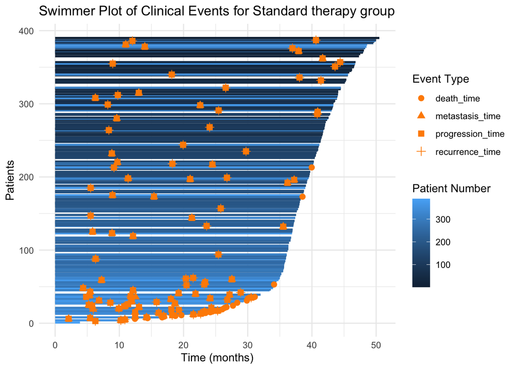

```r
swim_order %>%
  filter(itt_group == "Standard therapy group") %>%
  ggplot() +
  geom_segment(
    aes(x = 0, xend = followup_time,
      y = order, yend = order,
      color = no),
    linewidth = 1) +
  geom_point(
    data = swim_event,
    aes(
      x = event_time,
      y = order,
      shape = event_type,
    ),
    size = 2.5,
    color = "darkorange"
  ) +
  labs(
    title = "Swimmer Plot of Clinical Events for Standard therapy group",
    x = "Time (months)",
    y = "Patients",
    color = "Patient Number",
    shape = "Event Type"
  )+theme_minimal()
```